# Optimal Treatment Analysis

## Outcome Variable

**Outcome Variable:** haz

## Predictor Variables

**Intervention Variable:** earlybf

**Adjustment Set:**

- arm
- sex
- W_mage
- meducyrs
- feducyrs
- hhwealth_quart
- hfoodsec
- W_mhtcm
- W_mwtkg
- W_mbmi
- vagbrth
- W_gagebrth
- W_birthwt
- W_birthlen
- W_nrooms
- W_nchldlt5
- brthmon
- W_parity
- impfloor
- impsan
- safeh20
- delta_W_mage
- delta_meducyrs
- delta_feducyrs
- delta_hhwealth_quart
- delta_hfoodsec
- delta_W_mhtcm
- delta_W_mwtkg
- delta_W_mbmi
- delta_vagbrth
- delta_W_gagebrth
- delta_W_birthwt
- delta_W_birthlen
- delta_W_nrooms
- delta_W_nchldlt5
- delta_brthmon
- delta_W_parity
- delta_impfloor
- delta_impsan
- delta_safeh20

## Stratifying Variables

The analysis was stratified on these variable(s):

- agecat
- studyid
- country

## Data Summary

| agecat | studyid | country | earlybf | n_cell | n |
| --- | --- | --- | --- | --- | --- |
| Birth | ki0047075b-MAL-ED | BANGLADESH | 1 | 147 | 230 |
| Birth | ki0047075b-MAL-ED | BANGLADESH | 0 | 83 | 230 |
| Birth | ki0047075b-MAL-ED | BRAZIL | 1 | 28 | 65 |
| Birth | ki0047075b-MAL-ED | BRAZIL | 0 | 37 | 65 |
| Birth | ki0047075b-MAL-ED | INDIA | 1 | 32 | 46 |
| Birth | ki0047075b-MAL-ED | INDIA | 0 | 14 | 46 |
| Birth | ki0047075b-MAL-ED | NEPAL | 1 | 14 | 27 |
| Birth | ki0047075b-MAL-ED | NEPAL | 0 | 13 | 27 |
| Birth | ki0047075b-MAL-ED | PERU | 1 | 175 | 233 |
| Birth | ki0047075b-MAL-ED | PERU | 0 | 58 | 233 |
| Birth | ki0047075b-MAL-ED | SOUTH AFRICA | 1 | 69 | 111 |
| Birth | ki0047075b-MAL-ED | SOUTH AFRICA | 0 | 42 | 111 |
| Birth | ki0047075b-MAL-ED | TANZANIA, UNITED REPUBLIC OF | 1 | 111 | 125 |
| Birth | ki0047075b-MAL-ED | TANZANIA, UNITED REPUBLIC OF | 0 | 14 | 125 |
| Birth | ki1000109-EE | PAKISTAN | 1 | 44 | 229 |
| Birth | ki1000109-EE | PAKISTAN | 0 | 185 | 229 |
| Birth | ki1000304b-SAS-CompFeed | INDIA | 1 | 86 | 1207 |
| Birth | ki1000304b-SAS-CompFeed | INDIA | 0 | 1121 | 1207 |
| Birth | ki1017093c-NIH-Crypto | BANGLADESH | 1 | 634 | 732 |
| Birth | ki1017093c-NIH-Crypto | BANGLADESH | 0 | 98 | 732 |
| Birth | ki1113344-GMS-Nepal | NEPAL | 1 | 180 | 632 |
| Birth | ki1113344-GMS-Nepal | NEPAL | 0 | 452 | 632 |
| Birth | ki1126311-ZVITAMBO | ZIMBABWE | 1 | 6556 | 12354 |
| Birth | ki1126311-ZVITAMBO | ZIMBABWE | 0 | 5798 | 12354 |
| Birth | kiGH5241-JiVitA-3 | BANGLADESH | 1 | 236 | 22370 |
| Birth | kiGH5241-JiVitA-3 | BANGLADESH | 0 | 22134 | 22370 |
| Birth | kiGH5241-JiVitA-4 | BANGLADESH | 1 | 1912 | 2823 |
| Birth | kiGH5241-JiVitA-4 | BANGLADESH | 0 | 911 | 2823 |
| 6 months | ki0047075b-MAL-ED | BANGLADESH | 1 | 147 | 240 |
| 6 months | ki0047075b-MAL-ED | BANGLADESH | 0 | 93 | 240 |

[output cut: 52 more lines]

The following strata were considered:

- agecat: 24 months, studyid: ki0047075b-MAL-ED, country: BANGLADESH
- agecat: 24 months, studyid: ki0047075b-MAL-ED, country: BRAZIL
- agecat: 24 months, studyid: ki0047075b-MAL-ED, country: INDIA
- agecat: 24 months, studyid: ki0047075b-MAL-ED, country: NEPAL
- agecat: 24 months, studyid: ki0047075b-MAL-ED, country: PERU
- agecat: 24 months, studyid: ki0047075b-MAL-ED, country: SOUTH AFRICA
- agecat: 24 months, studyid: ki0047075b-MAL-ED, country: TANZANIA, UNITED REPUBLIC OF
- agecat: 24 months, studyid: ki1000109-EE, country: PAKISTAN
- agecat: 24 months, studyid: ki1017093c-NIH-Crypto, country: BANGLADESH
- agecat: 24 months, studyid: ki1113344-GMS-Nepal, country: NEPAL
- agecat: 24 months, studyid: ki1126311-ZVITAMBO, country: ZIMBABWE
- agecat: 24 months, studyid: kiGH5241-JiVitA-3, country: BANGLADESH
- agecat: 24 months, studyid: kiGH5241-JiVitA-4, country: BANGLADESH
- agecat: 6 months, studyid: ki0047075b-MAL-ED, country: BANGLADESH
- agecat: 6 months, studyid: ki0047075b-MAL-ED, country: BRAZIL
- agecat: 6 months, studyid: ki0047075b-MAL-ED, country: INDIA
- agecat: 6 months, studyid: ki0047075b-MAL-ED, country: NEPAL
- agecat: 6 months, studyid: ki0047075b-MAL-ED, country: PERU
- agecat: 6 months, studyid: ki0047075b-MAL-ED, country: SOUTH AFRICA
- agecat: 6 months, studyid: ki0047075b-MAL-ED, country: TANZANIA, UNITED REPUBLIC OF
- agecat: 6 months, studyid: ki1000109-EE, country: PAKISTAN
- agecat: 6 months, studyid: ki1000304b-SAS-CompFeed, country: INDIA
- agecat: 6 months, studyid: ki1017093c-NIH-Crypto, country: BANGLADESH
- agecat: 6 months, studyid: ki1113344-GMS-Nepal, country: NEPAL
- agecat: 6 months, studyid: ki1126311-ZVITAMBO, country: ZIMBABWE
- agecat: 6 months, studyid: kiGH5241-JiVitA-3, country: BANGLADESH
- agecat: 6 months, studyid: kiGH5241-JiVitA-4, country: BANGLADESH
- agecat: Birth, studyid: ki0047075b-MAL-ED, country: BANGLADESH
- agecat: Birth, studyid: ki0047075b-MAL-ED, country: BRAZIL
- agecat: Birth, studyid: ki0047075b-MAL-ED, country: INDIA
- agecat: Birth, studyid: ki0047075b-MAL-ED, country: NEPAL
- agecat: Birth, studyid: ki0047075b-MAL-ED, country: PERU
- agecat: Birth, studyid: ki0047075b-MAL-ED, country: SOUTH AFRICA
- agecat: Birth, studyid: ki0047075b-MAL-ED, country: TANZANIA, UNITED REPUBLIC OF
- agecat: Birth, studyid: ki1000109-EE, country: PAKISTAN
- agecat: Birth, studyid: ki1000304b-SAS-CompFeed, country: INDIA
- agecat: Birth, studyid: ki1017093c-NIH-Crypto, country: BANGLADESH
- agecat: Birth, studyid: ki1113344-GMS-Nepal, country: NEPAL
- agecat: Birth, studyid: ki1126311-ZVITAMBO, country: ZIMBABWE
- agecat: Birth, studyid: kiGH5241-JiVitA-3, country: BANGLADESH
- agecat: Birth, studyid: kiGH5241-JiVitA-4, country: BANGLADESH

### Dropped Strata

Some strata were dropped due to rare outcomes:

- agecat: 24 months, studyid: kiGH5241-JiVitA-3, country: BANGLADESH

## Methods Detail

We’re interested in the causal parameters $E[Y_a]$ for all values of $a \in \mathcal{A}$. These parameters represent the mean outcome if, possibly contrary to fact, we intervened to set all units to have $A=a$. Under the randomization and positivity assumptions, these are identified by the statistical parameters $\psi_a=E_W[E_{Y|A,W}(Y|A=a,W)]$. In addition, we’re interested in the mean of $Y$, $E[Y]$ under no intervention (the observed mean). We will estimate these parameters by using SuperLearner to fit the relevant likelihood factors – $E_{Y|A,W}(Y|A=a,W)$ and $p(A=a|W)$, and then updating our likelihood fit using a joint TMLE.

For unadjusted analyses ($W=\{\}$), initial likelihoods were estimated using Lrnr_glm to estimate the simple $E(Y|A)$ and Lrnr_mean to estimate $p(A)$. For adjusted analyses, a small library containing Lrnr_glmnet, Lrnr_xgboost, and Lrnr_mean was used.

Having estimated these parameters, we will then use the delta method to estimate relative risks and attributable risks relative to a prespecified baseline level of $A$.

# Results Detail

## Results Plots

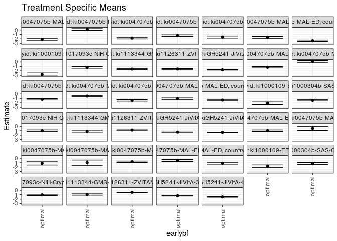

## Results Table

### Parameter: TSM

| agecat | studyid | country | intervention_level | baseline_level | estimate | ci_lower | ci_upper |
| --- | --- | --- | --- | --- | --- | --- | --- |
| Birth | ki0047075b-MAL-ED | BANGLADESH | optimal | observed | -0.9823815 | -1.1417273 | -0.8230358 |
| Birth | ki0047075b-MAL-ED | BRAZIL | optimal | observed | -0.4761614 | -0.9522147 | -0.0001082 |
| Birth | ki0047075b-MAL-ED | INDIA | optimal | observed | -1.1604857 | -1.5276946 | -0.7932767 |
| Birth | ki0047075b-MAL-ED | NEPAL | optimal | observed | -0.9930143 | -1.5839157 | -0.4021130 |
| Birth | ki0047075b-MAL-ED | PERU | optimal | observed | -0.7873945 | -0.9434317 | -0.6313572 |
| Birth | ki0047075b-MAL-ED | SOUTH AFRICA | optimal | observed | -0.5071366 | -0.7238472 | -0.2904259 |
| Birth | ki0047075b-MAL-ED | TANZANIA, UNITED REPUBLIC OF | optimal | observed | -1.1184152 | -1.3335917 | -0.9032387 |
| Birth | ki1000109-EE | PAKISTAN | optimal | observed | -1.7754743 | -2.0429576 | -1.5079911 |
| Birth | ki1000304b-SAS-CompFeed | INDIA | optimal | observed | -1.1857407 | -1.4389465 | -0.9325349 |
| Birth | ki1017093c-NIH-Crypto | BANGLADESH | optimal | observed | -1.0451765 | -1.1946210 | -0.8957321 |
| Birth | ki1113344-GMS-Nepal | NEPAL | optimal | observed | -0.9586495 | -1.1042384 | -0.8130606 |
| Birth | ki1126311-ZVITAMBO | ZIMBABWE | optimal | observed | -0.4648890 | -0.4955921 | -0.4341859 |
| Birth | kiGH5241-JiVitA-3 | BANGLADESH | optimal | observed | -1.2347807 | -1.3023550 | -1.1672063 |
| Birth | kiGH5241-JiVitA-4 | BANGLADESH | optimal | observed | -1.5082150 | -1.5655698 | -1.4508602 |
| 6 months | ki0047075b-MAL-ED | BANGLADESH | optimal | observed | -1.1728875 | -1.3204908 | -1.0252842 |
| 6 months | ki0047075b-MAL-ED | BRAZIL | optimal | observed | 0.1281837 | -0.0676175 | 0.3239848 |
| 6 months | ki0047075b-MAL-ED | INDIA | optimal | observed | -1.1972506 | -1.3491422 | -1.0453589 |
| 6 months | ki0047075b-MAL-ED | NEPAL | optimal | observed | -0.4739138 | -0.6261049 | -0.3217228 |
| 6 months | ki0047075b-MAL-ED | PERU | optimal | observed | -1.4437541 | -1.6186611 | -1.2688470 |
| 6 months | ki0047075b-MAL-ED | SOUTH AFRICA | optimal | observed | -1.0530205 | -1.2159089 | -0.8901321 |
| 6 months | ki0047075b-MAL-ED | TANZANIA, UNITED REPUBLIC OF | optimal | observed | -1.3766588 | -1.5454793 | -1.2078383 |
| 6 months | ki1000109-EE | PAKISTAN | optimal | observed | -2.0855828 | -2.3748841 | -1.7962816 |
| 6 months | ki1000304b-SAS-CompFeed | INDIA | optimal | observed | -1.4347740 | -1.5647843 | -1.3047638 |
| 6 months | ki1017093c-NIH-Crypto | BANGLADESH | optimal | observed | -1.0077958 | -1.2038450 | -0.8117466 |
| 6 months | ki1113344-GMS-Nepal | NEPAL | optimal | observed | -1.1622946 | -1.3103495 | -1.0142397 |
| 6 months | ki1126311-ZVITAMBO | ZIMBABWE | optimal | observed | -0.8450979 | -0.8805589 | -0.8096369 |
| 6 months | kiGH5241-JiVitA-3 | BANGLADESH | optimal | observed | -1.3013431 | -1.3253799 | -1.2773064 |
| 6 months | kiGH5241-JiVitA-4 | BANGLADESH | optimal | observed | -1.3590308 | -1.4086985 | -1.3093632 |
| 24 months | ki0047075b-MAL-ED | BANGLADESH | optimal | observed | -2.1283876 | -2.2971269 | -1.9596484 |
| 24 months | ki0047075b-MAL-ED | BRAZIL | optimal | observed | 0.1495805 | -0.1171670 | 0.4163280 |
| 24 months | ki0047075b-MAL-ED | INDIA | optimal | observed | -1.8215765 | -2.0146232 | -1.6285297 |
| 24 months | ki0047075b-MAL-ED | NEPAL | optimal | observed | -1.2645825 | -1.4276465 | -1.1015185 |
| 24 months | ki0047075b-MAL-ED | PERU | optimal | observed | -1.5926675 | -1.8266754 | -1.3586597 |
| 24 months | ki0047075b-MAL-ED | SOUTH AFRICA | optimal | observed | -1.6541273 | -1.8638277 | -1.4444269 |
| 24 months | ki0047075b-MAL-ED | TANZANIA, UNITED REPUBLIC OF | optimal | observed | -2.4384816 | -2.6121915 | -2.2647718 |
| 24 months | ki1000109-EE | PAKISTAN | optimal | observed | -2.8132158 | -3.1589389 | -2.4674928 |
| 24 months | ki1017093c-NIH-Crypto | BANGLADESH | optimal | observed | -1.2164497 | -1.3909783 | -1.0419211 |
| 24 months | ki1113344-GMS-Nepal | NEPAL | optimal | observed | -1.5846479 | -1.7315944 | -1.4377013 |
| 24 months | ki1126311-ZVITAMBO | ZIMBABWE | optimal | observed | -1.5675266 | -1.6522048 | -1.4828485 |
| 24 months | kiGH5241-JiVitA-4 | BANGLADESH | optimal | observed | -1.7574766 | -1.8107794 | -1.7041739 |

### Parameter: E(Y)

| agecat | studyid | country | intervention_level | baseline_level | estimate | ci_lower | ci_upper |
| --- | --- | --- | --- | --- | --- | --- | --- |
| Birth | ki0047075b-MAL-ED | BANGLADESH | observed | observed | -1.1218261 | -1.2566576 | -0.9869945 |
| Birth | ki0047075b-MAL-ED | BRAZIL | observed | observed | -0.6760000 | -0.9521457 | -0.3998543 |
| Birth | ki0047075b-MAL-ED | INDIA | observed | observed | -1.2221739 | -1.5203945 | -0.9239534 |
| Birth | ki0047075b-MAL-ED | NEPAL | observed | observed | -0.8533333 | -1.2104864 | -0.4961803 |
| Birth | ki0047075b-MAL-ED | PERU | observed | observed | -0.8827897 | -1.0001058 | -0.7654736 |
| Birth | ki0047075b-MAL-ED | SOUTH AFRICA | observed | observed | -0.5709009 | -0.7569265 | -0.3848753 |
| Birth | ki0047075b-MAL-ED | TANZANIA, UNITED REPUBLIC OF | observed | observed | -1.1556000 | -1.3655361 | -0.9456639 |
| Birth | ki1000109-EE | PAKISTAN | observed | observed | -1.8713537 | -2.0647180 | -1.6779894 |
| Birth | ki1000304b-SAS-CompFeed | INDIA | observed | observed | -1.4072245 | -1.4817853 | -1.3326638 |
| Birth | ki1017093c-NIH-Crypto | BANGLADESH | observed | observed | -0.9094945 | -0.9809370 | -0.8380521 |
| Birth | ki1113344-GMS-Nepal | NEPAL | observed | observed | -1.0578481 | -1.1411010 | -0.9745953 |
| Birth | ki1126311-ZVITAMBO | ZIMBABWE | observed | observed | -0.4895257 | -0.5113672 | -0.4676841 |
| Birth | kiGH5241-JiVitA-3 | BANGLADESH | observed | observed | -1.5896710 | -1.6089649 | -1.5703770 |
| Birth | kiGH5241-JiVitA-4 | BANGLADESH | observed | observed | -1.5232908 | -1.5723277 | -1.4742539 |
| 6 months | ki0047075b-MAL-ED | BANGLADESH | observed | observed | -1.2056389 | -1.3233420 | -1.0879358 |
| 6 months | ki0047075b-MAL-ED | BRAZIL | observed | observed | 0.0475758 | -0.0963508 | 0.1915023 |
| 6 months | ki0047075b-MAL-ED | INDIA | observed | observed | -1.2115254 | -1.3298727 | -1.0931782 |
| 6 months | ki0047075b-MAL-ED | NEPAL | observed | observed | -0.5615819 | -0.6741832 | -0.4489807 |
| 6 months | ki0047075b-MAL-ED | PERU | observed | observed | -1.3236661 | -1.4316775 | -1.2156546 |
| 6 months | ki0047075b-MAL-ED | SOUTH AFRICA | observed | observed | -1.0598800 | -1.1885688 | -0.9311912 |
| 6 months | ki0047075b-MAL-ED | TANZANIA, UNITED REPUBLIC OF | observed | observed | -1.3687449 | -1.4907629 | -1.2467270 |
| 6 months | ki1000109-EE | PAKISTAN | observed | observed | -2.0838858 | -2.2054394 | -1.9623322 |
| 6 months | ki1000304b-SAS-CompFeed | INDIA | observed | observed | -1.4018563 | -1.4810585 | -1.3226541 |
| 6 months | ki1017093c-NIH-Crypto | BANGLADESH | observed | observed | -1.1986783 | -1.2700937 | -1.1272630 |
| 6 months | ki1113344-GMS-Nepal | NEPAL | observed | observed | -1.3175310 | -1.3993963 | -1.2356656 |
| 6 months | ki1126311-ZVITAMBO | ZIMBABWE | observed | observed | -0.8625370 | -0.8897591 | -0.8353150 |
| 6 months | kiGH5241-JiVitA-3 | BANGLADESH | observed | observed | -1.3130932 | -1.3362359 | -1.2899505 |
| 6 months | kiGH5241-JiVitA-4 | BANGLADESH | observed | observed | -1.3447940 | -1.3820261 | -1.3075620 |
| 24 months | ki0047075b-MAL-ED | BANGLADESH | observed | observed | -1.9735782 | -2.1004502 | -1.8467062 |
| 24 months | ki0047075b-MAL-ED | BRAZIL | observed | observed | 0.0061144 | -0.1625850 | 0.1748138 |
| 24 months | ki0047075b-MAL-ED | INDIA | observed | observed | -1.8861894 | -2.0110006 | -1.7613783 |
| 24 months | ki0047075b-MAL-ED | NEPAL | observed | observed | -1.3075877 | -1.4270718 | -1.1881037 |
| 24 months | ki0047075b-MAL-ED | PERU | observed | observed | -1.7524710 | -1.8736426 | -1.6312994 |
| 24 months | ki0047075b-MAL-ED | SOUTH AFRICA | observed | observed | -1.6365071 | -1.7722110 | -1.5008032 |
| 24 months | ki0047075b-MAL-ED | TANZANIA, UNITED REPUBLIC OF | observed | observed | -2.6455607 | -2.7807256 | -2.5103959 |
| 24 months | ki1000109-EE | PAKISTAN | observed | observed | -2.6678252 | -2.8138884 | -2.5217620 |
| 24 months | ki1017093c-NIH-Crypto | BANGLADESH | observed | observed | -1.4412646 | -1.5249156 | -1.3576135 |
| 24 months | ki1113344-GMS-Nepal | NEPAL | observed | observed | -1.8793783 | -1.9705101 | -1.7882464 |
| 24 months | ki1126311-ZVITAMBO | ZIMBABWE | observed | observed | -1.6006366 | -1.6621572 | -1.5391159 |
| 24 months | kiGH5241-JiVitA-4 | BANGLADESH | observed | observed | -1.7807218 | -1.8162478 | -1.7451958 |

### Parameter: PAR

| agecat | studyid | country | intervention_level | baseline_level | estimate | ci_lower | ci_upper |
| --- | --- | --- | --- | --- | --- | --- | --- |
| Birth | ki0047075b-MAL-ED | BANGLADESH | optimal | observed | -0.1394446 | -0.2460474 | -0.0328417 |
| Birth | ki0047075b-MAL-ED | BRAZIL | optimal | observed | -0.1998386 | -0.5943705 | 0.1946934 |
| Birth | ki0047075b-MAL-ED | INDIA | optimal | observed | -0.0616882 | -0.2801482 | 0.1567717 |
| Birth | ki0047075b-MAL-ED | NEPAL | optimal | observed | 0.1396810 | -0.2234243 | 0.5027864 |
| Birth | ki0047075b-MAL-ED | PERU | optimal | observed | -0.0953952 | -0.1929947 | 0.0022042 |
| Birth | ki0047075b-MAL-ED | SOUTH AFRICA | optimal | observed | -0.0637643 | -0.1995092 | 0.0719805 |
| Birth | ki0047075b-MAL-ED | TANZANIA, UNITED REPUBLIC OF | optimal | observed | -0.0371848 | -0.1273487 | 0.0529791 |
| Birth | ki1000109-EE | PAKISTAN | optimal | observed | -0.0958794 | -0.2924956 | 0.1007369 |
| Birth | ki1000304b-SAS-CompFeed | INDIA | optimal | observed | -0.2214838 | -0.4194395 | -0.0235281 |
| Birth | ki1017093c-NIH-Crypto | BANGLADESH | optimal | observed | 0.1356820 | 0.0072400 | 0.2641239 |
| Birth | ki1113344-GMS-Nepal | NEPAL | optimal | observed | -0.0991986 | -0.2188474 | 0.0204501 |
| Birth | ki1126311-ZVITAMBO | ZIMBABWE | optimal | observed | -0.0246367 | -0.0463599 | -0.0029134 |
| Birth | kiGH5241-JiVitA-3 | BANGLADESH | optimal | observed | -0.3548903 | -0.4210600 | -0.2887206 |
| Birth | kiGH5241-JiVitA-4 | BANGLADESH | optimal | observed | -0.0150758 | -0.0501569 | 0.0200053 |
| 6 months | ki0047075b-MAL-ED | BANGLADESH | optimal | observed | -0.0327514 | -0.1259874 | 0.0604846 |
| 6 months | ki0047075b-MAL-ED | BRAZIL | optimal | observed | -0.0806079 | -0.2174966 | 0.0562807 |
| 6 months | ki0047075b-MAL-ED | INDIA | optimal | observed | -0.0142749 | -0.1100443 | 0.0814946 |
| 6 months | ki0047075b-MAL-ED | NEPAL | optimal | observed | -0.0876681 | -0.1801790 | 0.0048428 |
| 6 months | ki0047075b-MAL-ED | PERU | optimal | observed | 0.1200880 | -0.0200853 | 0.2602613 |
| 6 months | ki0047075b-MAL-ED | SOUTH AFRICA | optimal | observed | -0.0068595 | -0.1390557 | 0.1253367 |
| 6 months | ki0047075b-MAL-ED | TANZANIA, UNITED REPUBLIC OF | optimal | observed | 0.0079139 | -0.1124589 | 0.1282867 |
| 6 months | ki1000109-EE | PAKISTAN | optimal | observed | 0.0016970 | -0.2517549 | 0.2551489 |
| 6 months | ki1000304b-SAS-CompFeed | INDIA | optimal | observed | 0.0329178 | -0.0679865 | 0.1338221 |
| 6 months | ki1017093c-NIH-Crypto | BANGLADESH | optimal | observed | -0.1908825 | -0.3733300 | -0.0084351 |
| 6 months | ki1113344-GMS-Nepal | NEPAL | optimal | observed | -0.1552364 | -0.2795863 | -0.0308864 |
| 6 months | ki1126311-ZVITAMBO | ZIMBABWE | optimal | observed | -0.0174391 | -0.0410691 | 0.0061909 |
| 6 months | kiGH5241-JiVitA-3 | BANGLADESH | optimal | observed | -0.0117501 | -0.0161186 | -0.0073815 |
| 6 months | kiGH5241-JiVitA-4 | BANGLADESH | optimal | observed | 0.0142368 | -0.0178821 | 0.0463557 |
| 24 months | ki0047075b-MAL-ED | BANGLADESH | optimal | observed | 0.1548094 | 0.0362150 | 0.2734039 |
| 24 months | ki0047075b-MAL-ED | BRAZIL | optimal | observed | -0.1434661 | -0.3166252 | 0.0296930 |
| 24 months | ki0047075b-MAL-ED | INDIA | optimal | observed | -0.0646130 | -0.2156604 | 0.0864344 |
| 24 months | ki0047075b-MAL-ED | NEPAL | optimal | observed | -0.0430052 | -0.1431795 | 0.0571690 |
| 24 months | ki0047075b-MAL-ED | PERU | optimal | observed | -0.1598034 | -0.3650726 | 0.0454658 |
| 24 months | ki0047075b-MAL-ED | SOUTH AFRICA | optimal | observed | 0.0176202 | -0.1365980 | 0.1718384 |
| 24 months | ki0047075b-MAL-ED | TANZANIA, UNITED REPUBLIC OF | optimal | observed | -0.2070791 | -0.3606190 | -0.0535392 |
| 24 months | ki1000109-EE | PAKISTAN | optimal | observed | 0.1453906 | -0.1407279 | 0.4315092 |
| 24 months | ki1017093c-NIH-Crypto | BANGLADESH | optimal | observed | -0.2248149 | -0.3918444 | -0.0577854 |
| 24 months | ki1113344-GMS-Nepal | NEPAL | optimal | observed | -0.2947304 | -0.4243204 | -0.1651405 |
| 24 months | ki1126311-ZVITAMBO | ZIMBABWE | optimal | observed | -0.0331099 | -0.0938545 | 0.0276346 |
| 24 months | kiGH5241-JiVitA-4 | BANGLADESH | optimal | observed | -0.0232452 | -0.0654477 | 0.0189573 |